# Clase 1 - R GEO

## Introducción

Hoy en día la información georreferenciada es cada vez más común. Esta disponibilidad de la información implica aprender a manipularla de manera adecuada. En primer lugar, debemos tener en claro qué tipo de información estamos utilizando. Señalemos entonces en primera instancia, tres figuras básicas que para trabajar: -Líneas -Puntos -Polígonos En segundo lugar, debemos tener las herramientas adecuadas para trabajar con esa información. Iremos sumando paquetes, pero en principio activamos dos paquetes imprescindibles: -sf (para el trabajo con información geográfica) -tidyverse (para la manipulación de tablas)

```r
#install.packages("sf")
#install.packages("tidyverserse")

library(sf)
library(tidyverse)
library(ggrepel)
library(units)
```

## Lectura

En primer lugar debemos conocer la manera de leer un archivo con información geográfica. Cargaremos un archivo .shp (shape) con la función st_read():

```r
caba <- st_read("bases_clase_1/comunas/comunas_wgs84.shp")
head(caba)
```

```
## Simple feature collection with 6 features and 6 fields
## Geometry type: MULTIPOLYGON
## Dimension:     XY
## Bounding box:  xmin: -58.53152 ymin: -34.64582 xmax: -58.3707 ymax: -34.53863
## Geodetic CRS:  WGS 84
##   ID         OBJETO COMUNAS
## 1  1 LIMITE COMUNAL       2
## 2  3 LIMITE COMUNAL       6
## 3  6 LIMITE COMUNAL      10
## 4  7 LIMITE COMUNAL      11
## 5  8 LIMITE COMUNAL      12
## 6  9 LIMITE COMUNAL      14
##                                                                           BARRIOS
## 1                                                                        RECOLETA
## 2                                                                       CABALLITO
## 3 FLORESTA - MONTE CASTRO - VELEZ SARSFIELD - VERSALLES - VILLA LURO - VILLA REAL
## 4         VILLA DEL PARQUE - VILLA  DEVOTO - VILLA GRAL. MITRE - VILLA SANTA RITA
## 5                           COGHLAN - SAAVEDRA - VILLA PUEYRREDON - VILLA URQUIZA
## 6                                                                         PALERMO
##   PERIMETRO     AREA                       geometry
## 1  21452.84  6317265 MULTIPOLYGON (((-58.38 -34....
## 2  10990.96  6851029 MULTIPOLYGON (((-58.43061 -...
## 3  18332.04 12656557 MULTIPOLYGON (((-58.48834 -...
## 4  19987.70 14120042 MULTIPOLYGON (((-58.49838 -...
## 5  17232.19 15570927 MULTIPOLYGON (((-58.50331 -...
## 6  22126.53 15845871 MULTIPOLYGON (((-58.42676 -...
```

Tal como podemos observar, el archivo devuelve información sobre nuestro objeto geográfico. Tipo: Multipolígono Bounding box: límites de los ejes CRS: sistema de coordenadas de referencia Archivo: shape file (.shp una de las extensiones entre otras que permiten almacenar información geográfica). Ya podemos entonces, visualizar la información disponible en nuestro objeto. La información relevante del objeto remite principalmente a las distintas comunas que conforman la Ciudad autónoma de Buenos Aires y los límites de cada uno de los polígonos que conforman esas comunas. Pasemos entonces a la visualización de este mapa utilizando el conocido ggplot() con la función geom_sf()

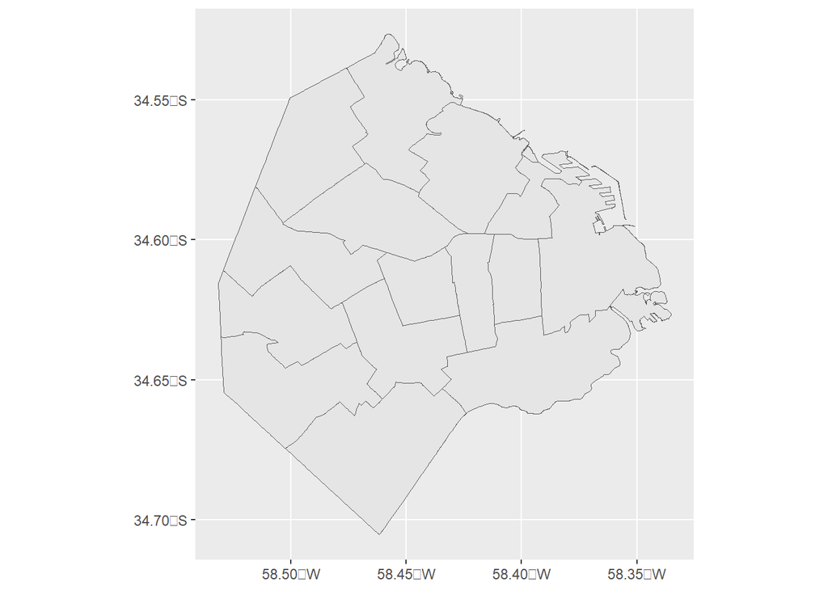

```r
ggplot(data=caba)+
  geom_sf()
```

¡Simple! Con sólo dos líneas de código, pudimos visualizar el contorno de la CABA y sus respectivas comunas. Agreguemos ahora un color por comuna para distinguir esas comunas.

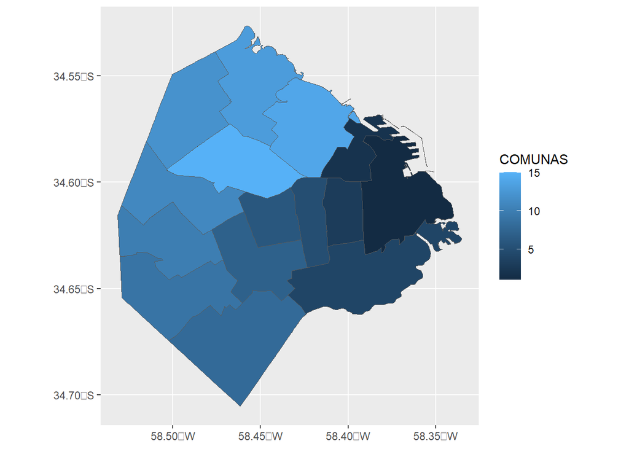

```r
ggplot(data=caba)+
  geom_sf(aes(fill= COMUNAS))
```

¿Qué sucedió? Si bien distingue las comunas, entiende el número de comuna como una variable de rango numérico. Lo adecuado sería tener una variable categórica. Por ese motivo, recurrimos a tidyverse para modificar esa variable:

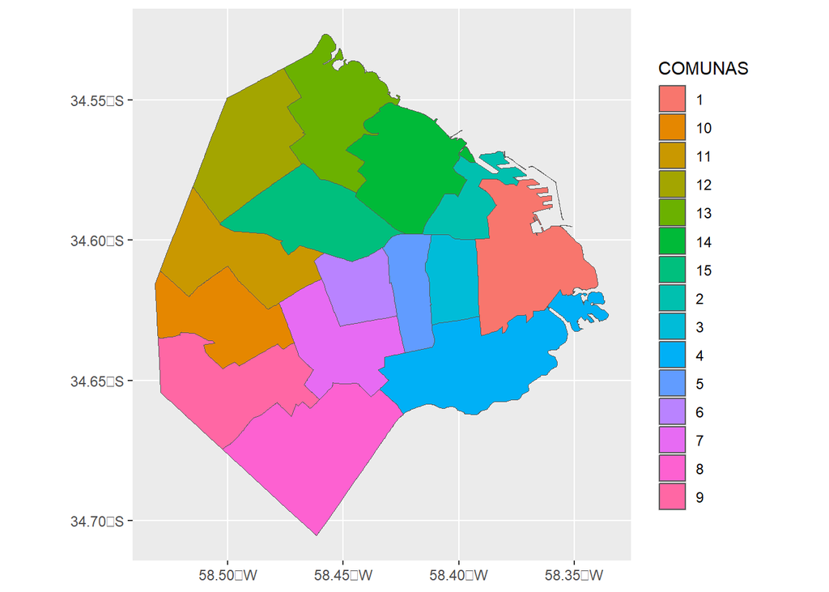

```r
caba <- caba %>%
  mutate(COMUNAS = as.character(COMUNAS))

ggplot(data=caba)+
  geom_sf(aes(fill= COMUNAS))
```

Genial, sin embargo, un nuevo inconveniente se presenta. El orden de las comunas es ahora categórico y tal como podemos ver, no es el que nosotros querríamos mostrar. Afortunadamente, existe una manera de ordenar esta variable, transformando el dato en tipo factor:

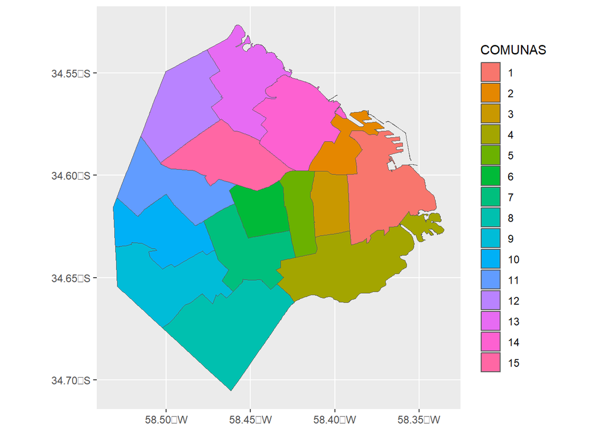

```r
caba <- caba %>%
  mutate(COMUNAS = factor(COMUNAS, levels=1:15))


ggplot(data=caba)+
  geom_sf(aes(fill= COMUNAS))
```

Si quisiéramos quitar la leyenda, no tenemos más que aclararlo en el código:

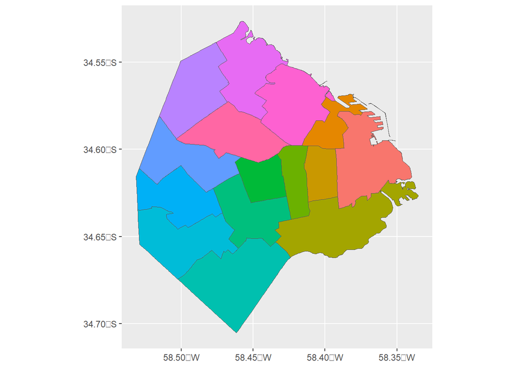

```r
ggplot(data=caba)+
  geom_sf(aes(fill= COMUNAS))+
  theme(legend.position = "None")
```

Podemos también quitar las coordenadas geográficas y agregar un título:

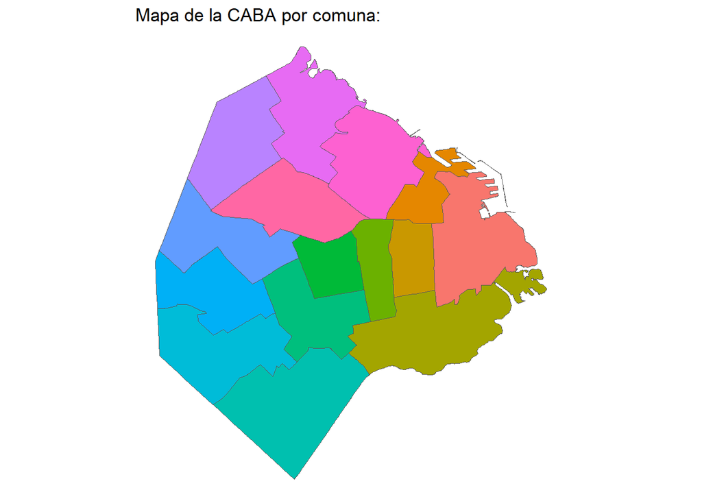

```r
ggplot(data=caba)+
  geom_sf(aes(fill= COMUNAS))+
  labs(title = "Mapa de la CABA por comuna:")+
  theme_void()+
  theme(legend.position = "None")
```

Sigamos agregando información relevante para nuestro mapa. Una avenida importante es Av. Rivadavia (que se suele usar para dividir el norte y el sur de la ciudad). Para cargar objetos de información geográfica, tenemos también la chance de hacerlo directamente a través de un link. Lo haremos con el link de datos abiertos del gobierno de la ciudad:

```r
rivadavia <- st_read("https://cdn.buenosaires.gob.ar/datosabiertos/datasets/jefatura-de-gabinete-de-ministros/calles/avenida_rivadavia.geojson")
```

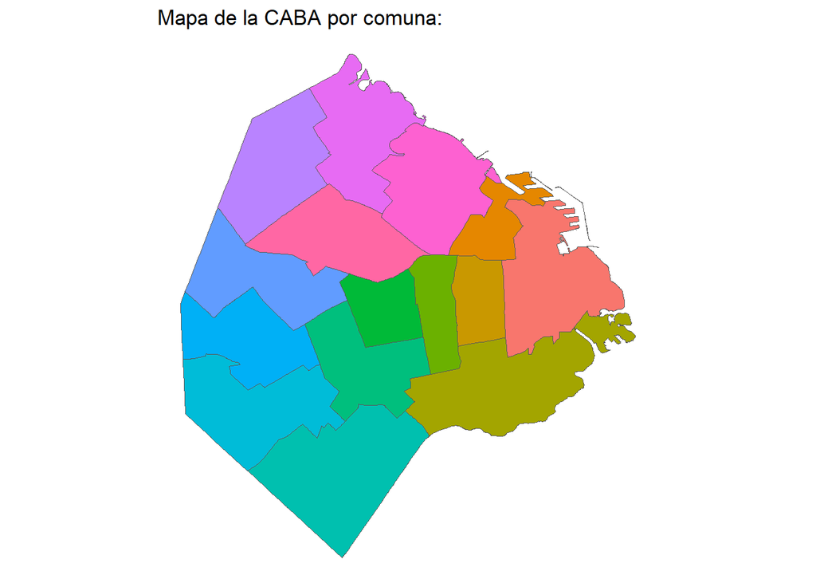

```r
ggplot(data=caba)+
  geom_sf(data=rivadavia, aes(col="red"))+
  geom_sf(aes(fill= COMUNAS))+
  labs(title = "Mapa de la CABA por comuna:")+
  theme_void()+
  theme(legend.position = "None")
```

¿Qué pasó? El mapa se despliega, no tira error y sin embargo, la avenida no aparece. Es importante tener en cuenta que la información geográfica se despliega a través de capas que se superponen una sobre otra. El orden de las capas se dispone en función del orden del código. En este caso, pusimos primero la avenida y luego el polígono de la capital. Lo que sucede es que la avenida está en nuestra imagen pero no se ve porque está tapada por el polígono. Hagamos lo mismo entonces pero cambiando el orden de las capas:

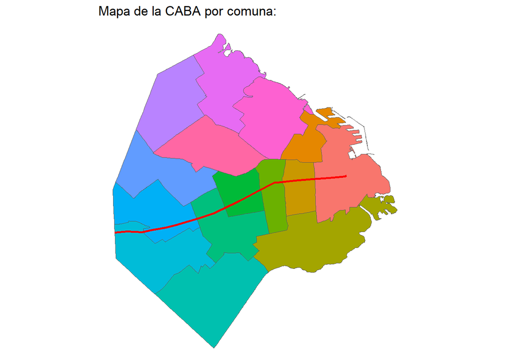

```r
ggplot(data=caba)+
  geom_sf(aes(fill= COMUNAS))+
  geom_sf(data=rivadavia, col="red", lwd=1)+
  labs(title = "Mapa de la CABA por comuna:")+
  theme_void()+
  theme(legend.position = "None")
```

¡Ahora sí! Obtenemos el mapa de la CABA dividido por la Av. Rivadavia. ¿Qué pasa si queremos entonces etiquetar las comunas? Las comunas son polígonos y la etiqueta debe situarse en un punto fijo. Por lo tanto, deberíamos obtener un punto a partir de los polígonos. La forma de realizarlo es obtener el centroide del polígono y ahí situar la etiqueta.

```r
caba2 <- caba  %>%
  mutate(lon = map_dbl(geometry, ~st_point_on_surface(.x)[[1]]),
         lat = map_dbl(geometry, ~st_point_on_surface(.x)[[2]]))
```

Graficamos.

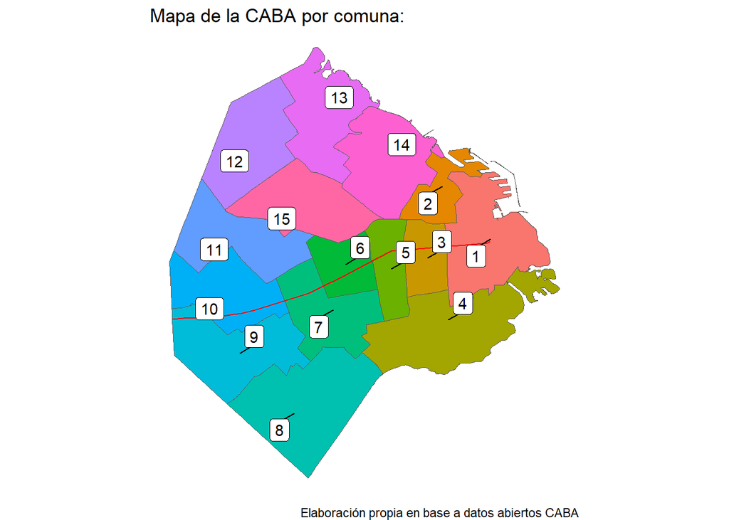

```r
ggplot() +
  geom_sf(data = caba2, aes(fill=COMUNAS)) +
  geom_sf(data=rivadavia, col="red")+
  geom_label_repel(data = caba2, aes(x = lon, y = lat, label = COMUNAS))+
  labs(title = "Mapa de la CABA por comuna:",
       caption="Elaboración propia en base a datos abiertos CABA")+
  theme_void()+
  theme(legend.position = "None")
```

Vayamos ahora a una temática específica. Establecimientos educativos. En primer lugar, cargamos la base que contiene los establecimientos educativos. Grafiquemos.

```r
escuelas <- st_read("bases_clase_1/establecimientos_educativos/establecimientos_educativos_wgs84.shp")
```

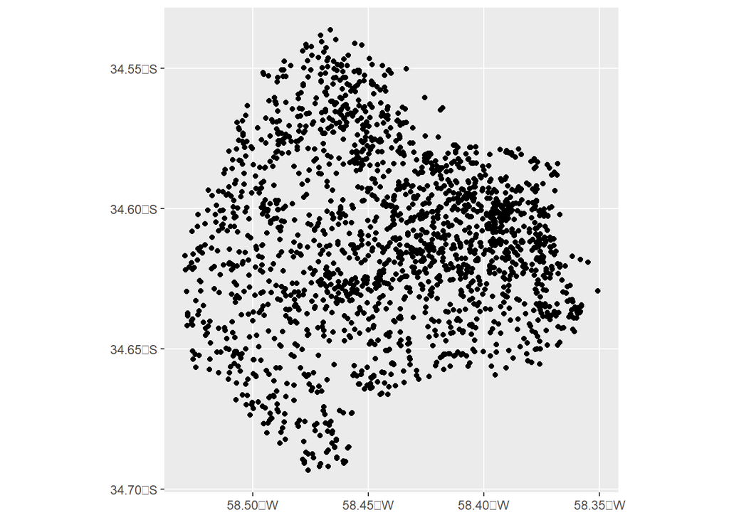

```r
ggplot(data=escuelas)+
  geom_sf()
```

En principio, vemos que existen establecimientos educativos a prácticamente toda la ciudad. Agrupemos entonces por comuna y veamos si efectivamente los establecimientos escolares se distribuyen de manera equitativa.

```r
establecimientos_agrupados <- escuelas %>%
  group_by(comuna) %>%
  summarise(cantidad = n())

establecimientos_agrupados <- establecimientos_agrupados %>%
  mutate(comuna = as.factor(comuna))
```

Realicemos un gráfico de barras que exprese la cantidad de establecimientos educativos por Comuna.

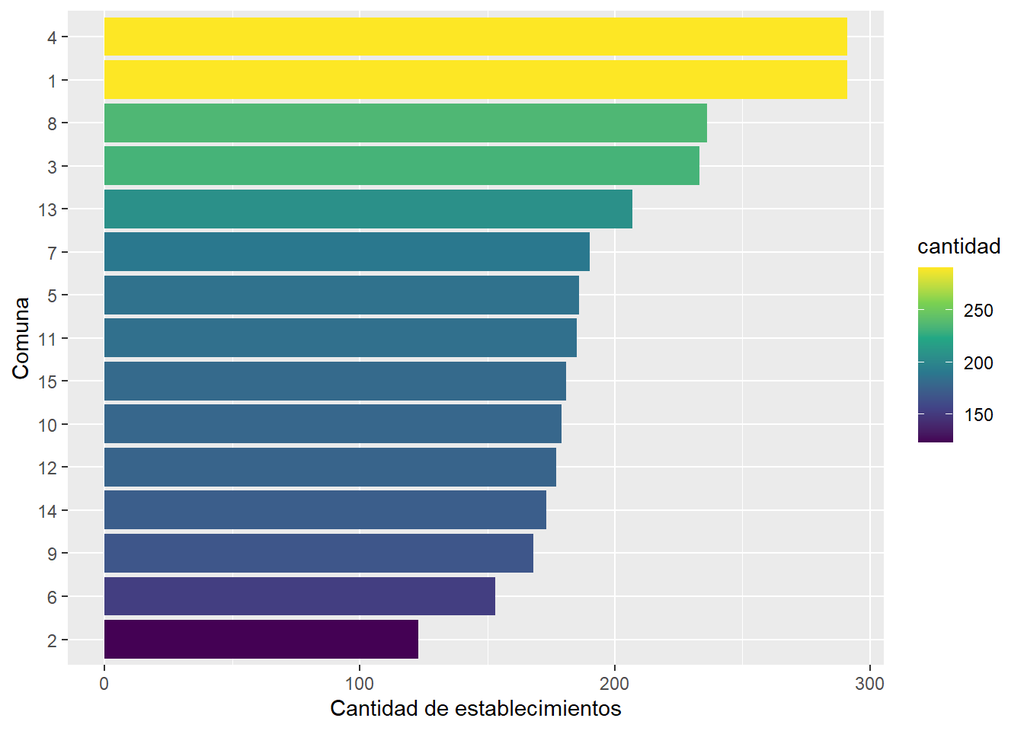

```r
ggplot(data = establecimientos_agrupados)+
  geom_col(aes(x= reorder(comuna,cantidad), y= cantidad, fill= cantidad))+
  labs(x= "Comuna", y= "Cantidad de establecimientos")+
  scale_fill_viridis_c()+
  coord_flip()
```

En la base que tenemos, los establecimientos no están agrupados. A través de un join, podemos agregar la cantidad de establecimientos a la comuna para visualizar el mapa.

```r
establecimientos_agrupados = as.data.frame(establecimientos_agrupados) %>%
  select(-3)


caba_establecimientos <- left_join(caba2, establecimientos_agrupados,
                                   by= c("COMUNAS" = "comuna"))


class(caba_establecimientos)
```

```
## [1] "sf"         "data.frame"
```

Ahora graficamos llenando color por cantidad y agregando la etiqueta.

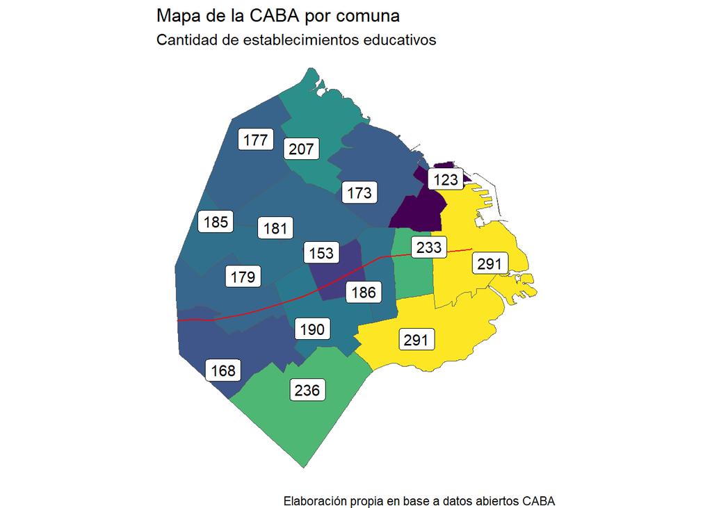

```r
ggplot() +
  geom_sf(data = caba_establecimientos, aes(fill=cantidad)) +
  geom_sf(data=rivadavia, col="red")+
  geom_label_repel(data = caba_establecimientos, aes(x = lon, y = lat, label = cantidad))+
  labs(title = "Mapa de la CABA por comuna",
       subtitle= "Cantidad de establecimientos educativos",
       caption="Elaboración propia en base a datos abiertos CABA")+
  scale_fill_viridis_c()+
  theme_void()+
  theme(legend.position = "None")
```

Trabajemos ahora con los radios censales.

```r
radios <- st_read("bases_clase_1/censal/informacion_censal_por_radio_2010_wgs84.shp")
```

Grafiquemos en primer lugar para visualizar los radios.

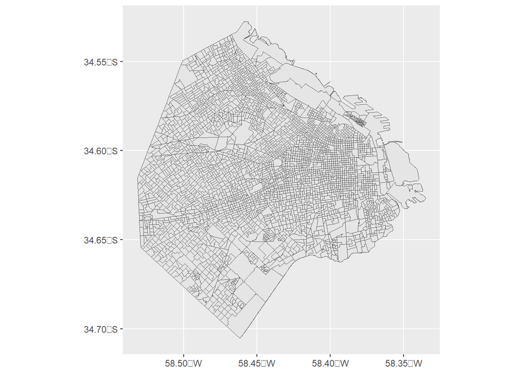

```r
ggplot()+
  geom_sf(data=radios)
```

Veamos la información que nos provee esta base.

```r
names(radios)
```

```
##  [1] "ID"         "CO_FRAC_RA" "COMUNA"     "FRACCION"   "RADIO"
##  [6] "TOTAL_POB"  "T_VARON"    "T_MUJER"    "T_VIVIENDA" "V_PARTICUL"
## [11] "V_COLECTIV" "T_HOGAR"    "H_CON_NBI"  "H_SIN_NBI"  "geometry"
```

Con esta base podemos por ejemplo cargar la cantidad de hogares con Necesidades básicas insatisfechas.

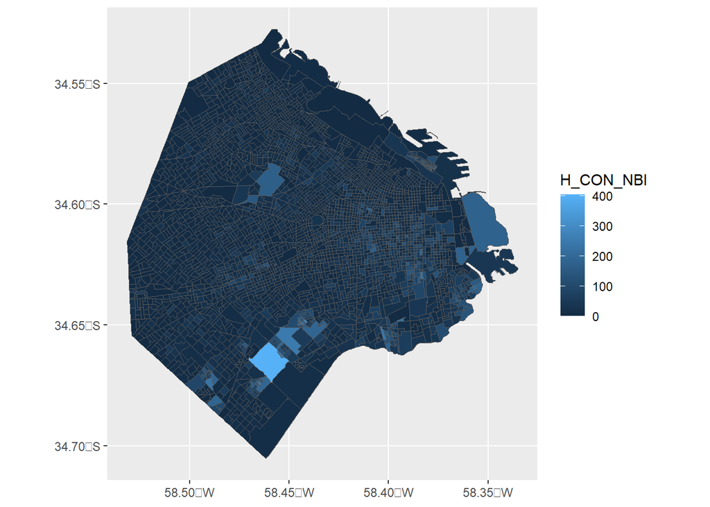

```r
ggplot(data = radios)+
  geom_sf(aes(fill=H_CON_NBI))
```

Los radios censales son unidades geográficas relativamente pequeñas por lo que muchas líneas atraviesan el mapa y pueden terminar resultando molestas a la visualización. Quitemos entonces las líneas para clarificar el mapa.

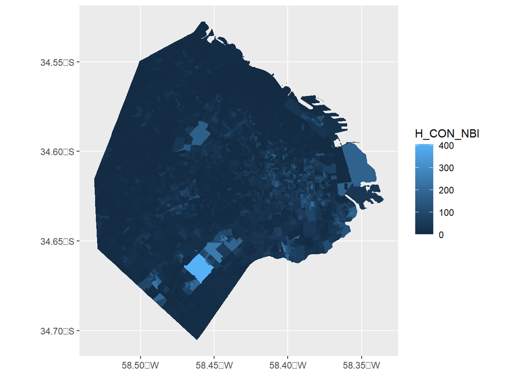

```r
ggplot(data = radios)+
  geom_sf( col =NA,aes(fill=H_CON_NBI))
```

De esta manera podemos clarificar las zonas donde hay mayores niveles de hogares con necesidades básicas insatisfechas. Podemos mejorar la visualización agregando una escala y agregar un nombre más adecuado

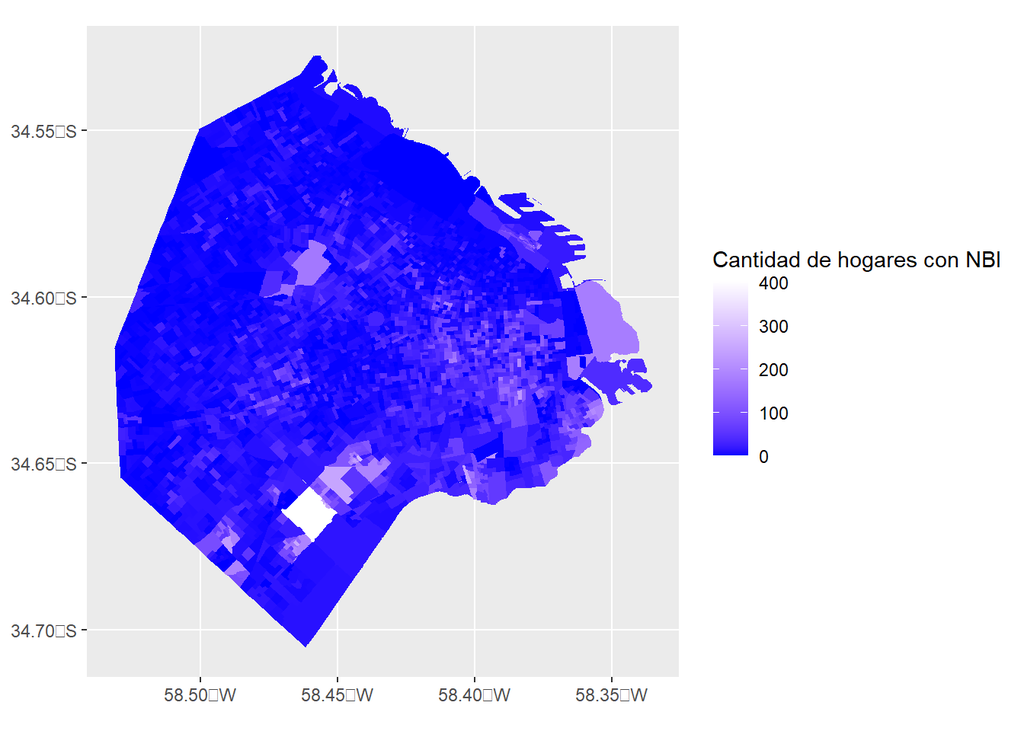

```r
ggplot(data = radios)+
  geom_sf( col =NA,aes(fill=H_CON_NBI))+
  scale_fill_gradient(low = "blue", high= "white",
                      name= "Cantidad de hogares con NBI")
```

Una de las características de los barrios populares es que poseen altos niveles de NBI. Carguemos la base que contiene los barrios populares de la CABA y veamos si coincide con los datos que estamos presentando.

```r
bpop <- st_read("bases_clase_1/bpop/barrios_vulnerables.shp")
```

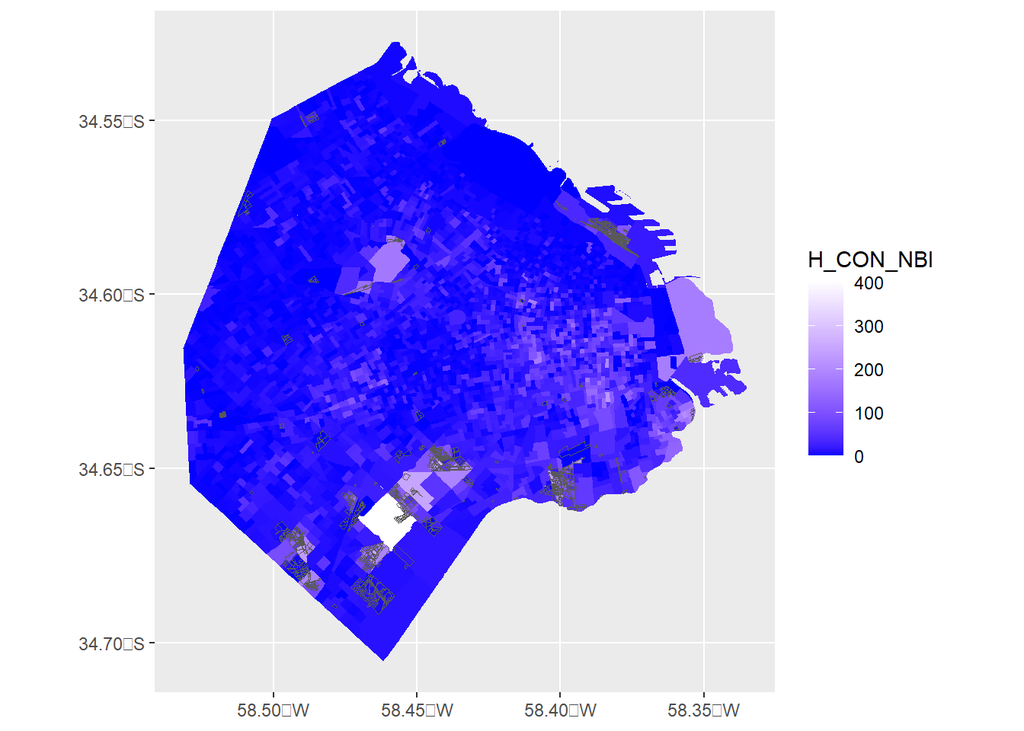

```r
ggplot(data = radios)+
  geom_sf( col =NA,aes(fill=H_CON_NBI))+
  geom_sf(data=bpop, fill=NA)+
  #geom_label_repel(data = bpop, aes(x = lon, y = lat, label = NOMBRE))
  scale_fill_gradient(low = "blue", high= "white")
```

Carguemos ahora las estaciones de subte:

```r
subte <- st_read("https://cdn.buenosaires.gob.ar/datosabiertos/datasets/sbase/subte-estaciones/estaciones-de-subte.geojson")
```

Graficamos las estaciones:

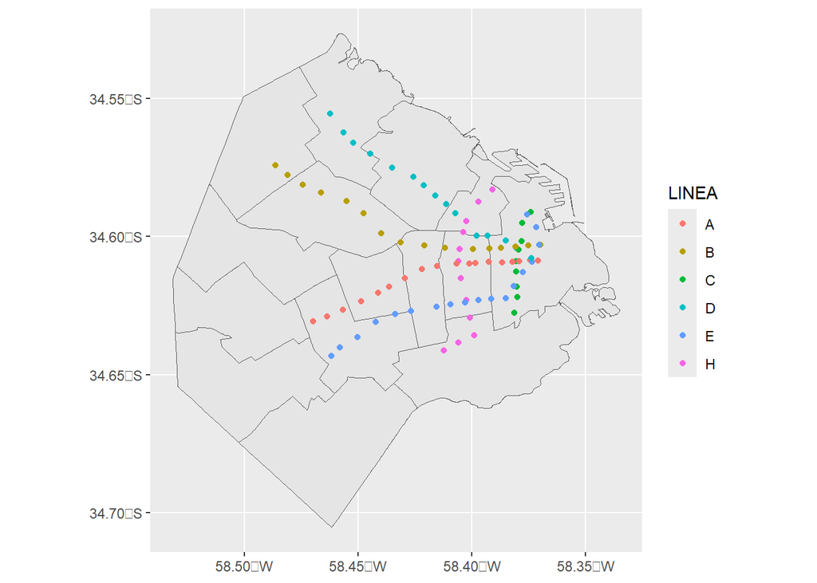

```r
ggplot()+
  geom_sf( data = caba)+
  geom_sf(data= subte, aes(col=LINEA) )
```

Carguemos las lineas.

```r
subte_lineas <- read_sf("bases_clase_1/lineas_subte.shp")
```

Graficamos nuevamente.

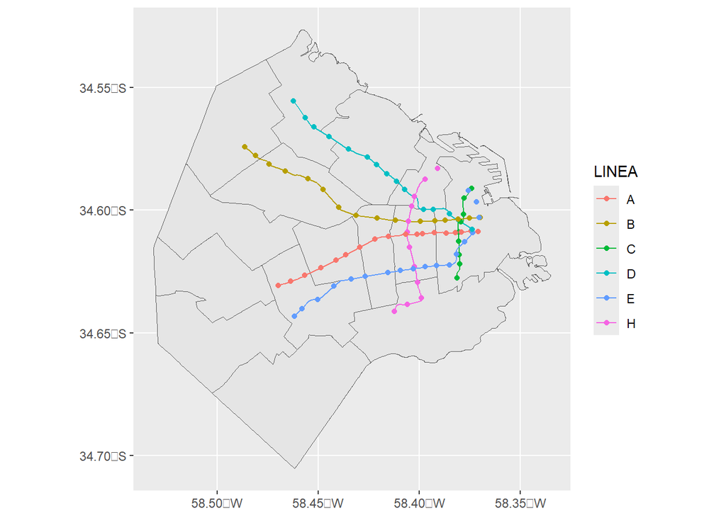

```r
ggplot()+
  geom_sf( data = caba)+
  geom_sf(data = subte_lineas, aes(col=LINEA))+
  geom_sf(data= subte, aes(col=LINEA) )
```

Las líneas tienen sin embargo un color específico. Cambiemos al color que corresponde.

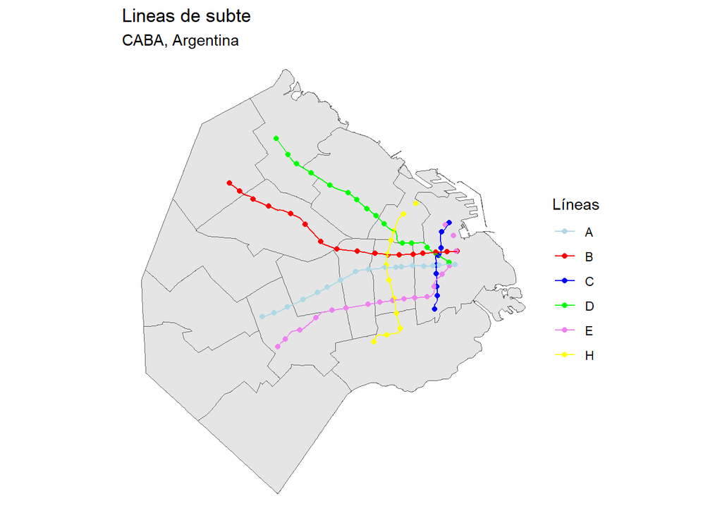

```r
ggplot()+
  geom_sf(data = caba)+
  geom_sf(data= subte, aes(col=LINEA) )+
  geom_sf(data= subte_lineas, aes(col=LINEA))+
  scale_color_manual(name = "Líneas",
                     values = c("A" = "lightblue",
                               "B" = "red",
                               "C" = "blue",
                               "D" = "green",
                               "E" = "violet",
                               "H" = "yellow"))+
  labs(title= "Lineas de subte", subtitle = "CABA, Argentina")+
  theme_void()
```

## Densidad poblacional

Si quisiéramos calcular la densidad poblacional por comuna debemos en primer lugar cargar la base que contiene la población por comuna.

```r
poblacion_comuna <- read.csv("bases_clase_1/gcba_pob_comunas_17.csv")

poblacion_comuna <- poblacion_comuna %>%
  mutate(COMUNA = as.character(COMUNA))
```

Luego, debemos realizar el join por número de comuna.

```r
poblacion_comuna <- left_join(caba, poblacion_comuna, by=c("COMUNAS" = "COMUNA"))
```

```r
sf_use_s2(FALSE)

poblacion_comuna <- poblacion_comuna %>%
  mutate(area_kms = AREA / 1000000,
          Densidad = POBLACION / area_kms)

# otra manera
poblacion_comuna <- poblacion_comuna %>%
  mutate(area_kms2 = as.numeric(round(set_units(st_area(poblacion_comuna$geometry), km2),2)))
```

Graficamos.

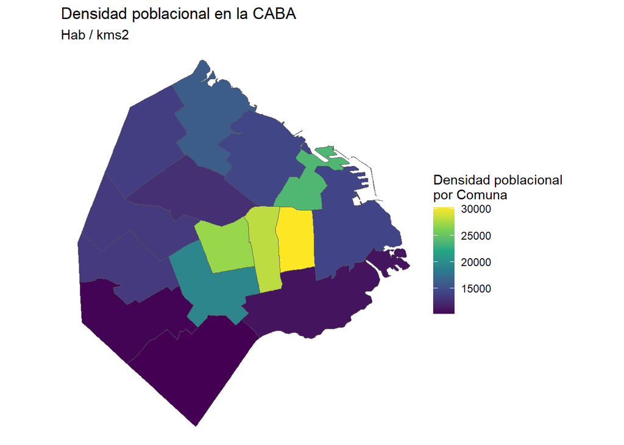

```r
ggplot()+
  geom_sf( data = caba)+
  geom_sf(data = poblacion_comuna, aes(fill = Densidad))+
  scale_fill_viridis_c(name = "Densidad poblacional\npor Comuna",
                       breaks= seq(10000,30000, 5000))+
  labs(title = "Densidad poblacional en la CABA",
       subtitle = "Hab / kms2")+
  theme_void()
```

Podemos agregar los barrios sobre este mapa para distinguir.

```r
barrios <- st_read("bases_clase_1/barrios_caba/barrios_wgs84.shp")
```

Podemos agregar los nombres de los barrios para tener más clara la distribución.

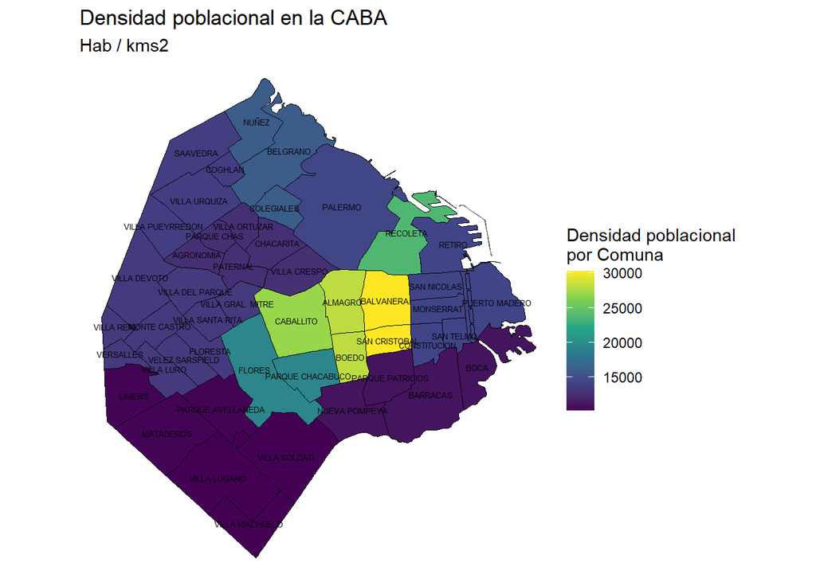

```r
barrios <- barrios  %>%
  mutate(lon = map_dbl(geometry, ~st_point_on_surface(.x)[[1]]),
         lat = map_dbl(geometry, ~st_point_on_surface(.x)[[2]]))


ggplot()+
  geom_sf( data = caba)+
  geom_sf(data = poblacion_comuna, aes(fill = Densidad))+
  geom_sf(data = barrios, fill=NA, col="black")+
    geom_text(data = barrios, aes(x = lon, y = lat, label = BARRIO),
               size=1.7)+
  scale_fill_viridis_c(name = "Densidad poblacional\npor Comuna",
                       breaks= seq(10000,30000, 5000))+
  labs(title = "Densidad poblacional en la CABA",
       subtitle = "Hab / kms2")+
  theme_void()
```

está disponible también el mapa de calles de la CABA.

```r
calles <- st_read("bases_clase_1/callejero.csv", crs = 4326 )
```

Grafiquemos las calles por barrio.

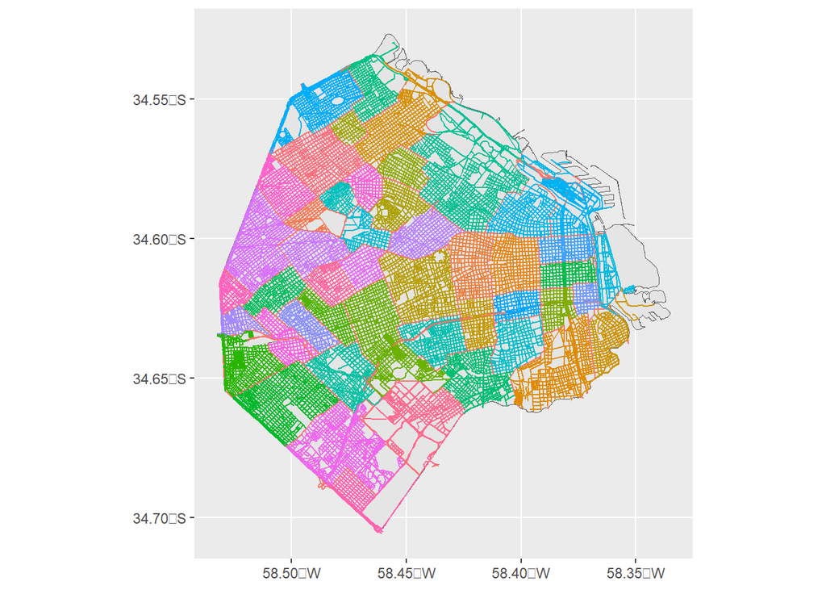

```r
ggplot()+
  geom_sf(data = caba)+
  geom_sf(data = calles, aes(col=BARRIO))+
  theme(legend.position = "None")
```

Podríamos destacar las avenidas.

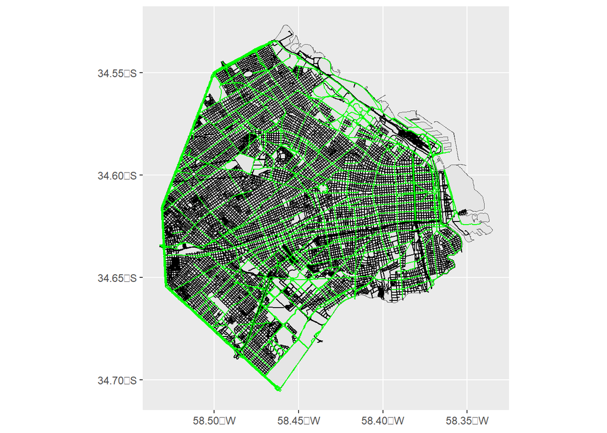

```r
ggplot()+
  geom_sf(data = caba)+
  geom_sf(data = calles)+
  geom_sf(data = filter(calles, tipo_c == "AVENIDA"), col="green")+
  theme(legend.position = "None")
```

¿Ciclovías?

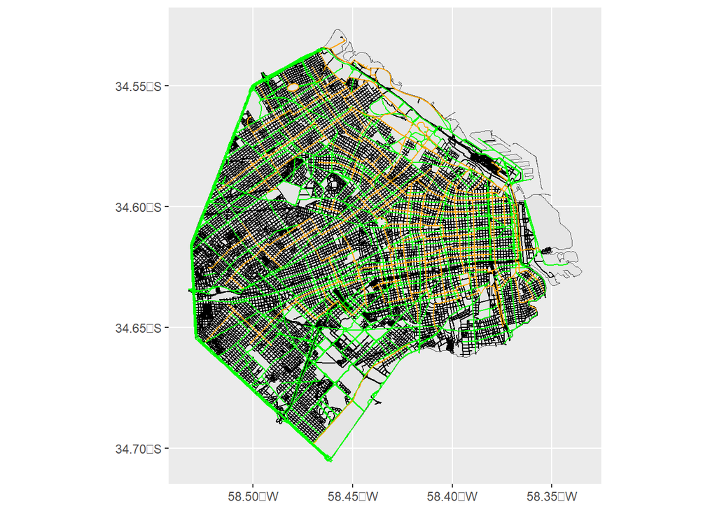

```r
ggplot()+
  geom_sf(data = caba)+
  geom_sf(data = calles)+
  geom_sf(data = filter(calles, tipo_c == "AVENIDA"), col="green")+
  geom_sf(data = filter(calles, bicisenda == "Ciclovías"), col= "orange")+
  theme(legend.position = "None")
```

De la misma manera podemos filtrar por comuna si queremos hacer alguna comparación.

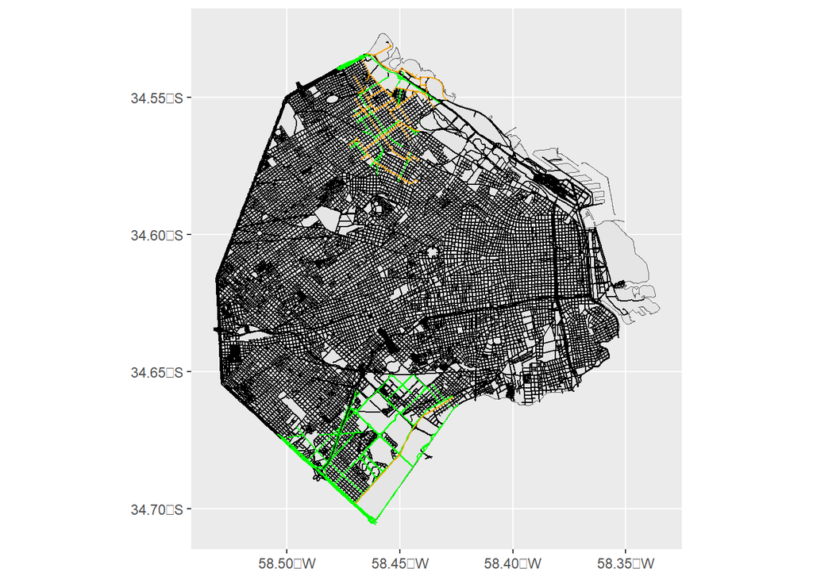

```r
ggplot()+
  geom_sf(data = caba)+
  geom_sf(data = calles)+
  geom_sf(data = filter(calles, tipo_c == "AVENIDA"
                        & COMUNA %in% c("13","8")), col="green")+
  geom_sf(data = filter(calles, bicisenda == "Ciclovías" & COMUNA %in% c("13","8")), col= "orange")+
 theme(legend.position = "None")
```

Agreguemos una leyenda.

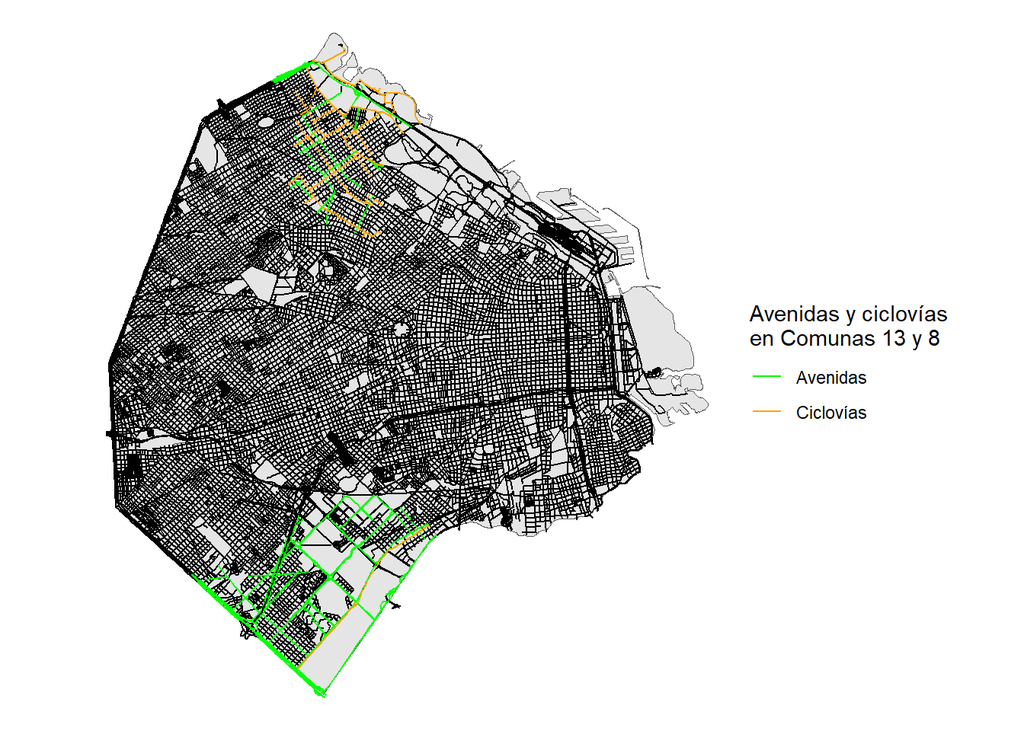

```r
ggplot()+
  geom_sf(data = caba)+
  geom_sf(data = calles)+
  geom_sf(data = filter(calles, tipo_c == "AVENIDA"
                        & COMUNA %in% c("13","8")), aes(col= "Avenidas"))+
  geom_sf(data = filter(calles, bicisenda == "Ciclovías" & COMUNA %in% c("13","8")),
          aes(col= "Ciclovías"))+
  scale_color_manual(name = "Avenidas y ciclovías\nen Comunas 13 y 8",
                     labels = c("Avenidas", "Ciclovías"),
                     values = c("Avenidas" = "green",
                                "Ciclovías" = "orange"))+
  theme_void()
```

Agregamos el contorno de la Comuna.

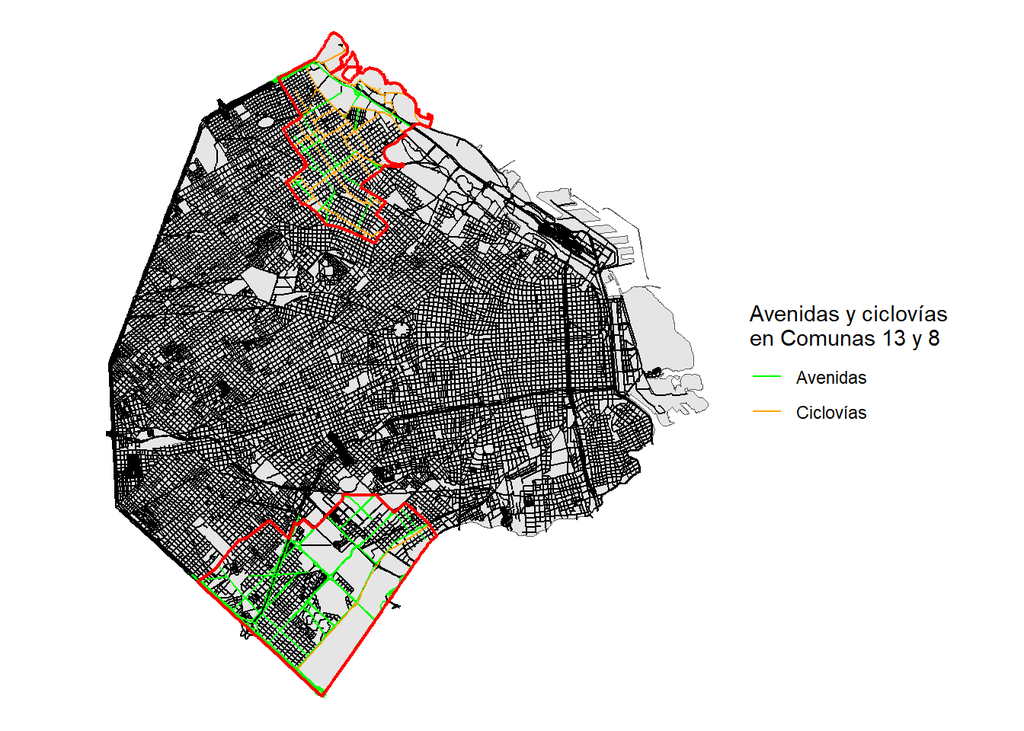

```r
ggplot()+
  geom_sf(data = caba)+
  geom_sf(data = calles)+
  geom_sf(data = filter(calles, tipo_c == "AVENIDA"
                        & COMUNA %in% c("13","8")), aes(col= "Avenidas"))+
  geom_sf(data = filter(calles, bicisenda == "Ciclovías" & COMUNA %in% c("13","8")),
          aes(col= "Ciclovías"))+
  geom_sf(data = filter(caba, COMUNAS %in% c("13", "8")), col="red", fill=NA, lwd=0.8)+
  scale_color_manual(name = "Avenidas y ciclovías\nen Comunas 13 y 8",
                     labels = c("Avenidas", "Ciclovías"),
                     values = c("Avenidas" = "green",
                                "Ciclovías" = "orange"))+
  theme_void()
```

Salvemos el mapa como imagen en formato .png En primer lugar, guardamos el mapa en un objeto.

```r
mapa_caba <- ggplot()+
              geom_sf(data = caba)+
              geom_sf(data = calles)+
              geom_sf(data = filter(calles, tipo_c == "AVENIDA"
                                    & COMUNA %in% c("13","8")), aes(col= "Avenidas"))+
              geom_sf(data = filter(calles, bicisenda == "Ciclovías" & COMUNA %in% c("13","8")),
                      aes(col= "Ciclovías"))+
              geom_sf(data = filter(caba, COMUNAS %in% c("13", "8")), col="red", fill=NA, lwd=1)+
              scale_color_manual(name = "Avenidas y ciclovías\nen Comunas 13 y 8",
                                 labels = c("Avenidas", "Ciclovías"),
                                 values = c("Avenidas" = "green",
                                            "Ciclovías" = "orange"))+
              theme_void()
```

Finalmente, lo guardamos con la función ggsave()

```r
ggsave("mapa_caba.png", dpi=300, bg="white")
```